# Analysis plan and power calculations for the NutriCare Study

Dan Spakowicz and Rebecca Hoyd

May 15, 2020

The purpose of this script is to describe and freeze a version of the analysis plan associated with the NutriCare Study, which is expected to open in September of 2020. Analysis is expected in late 2021.

# Overview of the NutriCare Study

The NutriCare Study will evaluate whether nutritional counseling and dietary modification affect the health and survival of high-risk patients undergoing treatment for lung cancer. The study will enroll 150 patients and randomize to a dietary intervention arm (3 home-delivered medically-tailored meals per day provided for 6 months plus individualized nutrition counseling provided by Registered Dietitians for 8 months) versus a passive nutrition education “enhanced control” arm.

# Hypothesis 1

## Strong baseline differences (regional, demographic) will result in the 3-month samples clustering (by non-metric multidimensional scaling) more closely with that individual’s baseline sample than with the other 3-month samples grouped by MTM category.

## Conversely, the 8-month samples will cluster more closely with other 8-month samples by MTM category, indicating the long-term dietary intervention shifted the microbiomes in a consistent way.

### Methods

Sample clustering by individual versus by time point will be the assessed within an NMDS plot. * Distances to the cluster centroid (normally distributed) will be compared between the NutriCare and NutriTool 8-month time point clusters. * Distances to cluster centroid between clusters assigned by individual (all three time-points), versus by MTM category (3-month (hypothesis 1) and 8-month (hypothesis 2) time points, separately)).

```r
MESS::power_t_test(delta = 10,
             sd = 5,
             power = 0.8,
             sig.level = 0.05,
             ratio = 5,
             sd.ratio = 5,
             type = "two.sample",
             alternative = "one.sided")
```

```
##
##      Two-sample t test power calculation with unequal sample sizes and unequal variances
##
##               n = 9.507852, 47.539259
##           delta = 10
##              sd = 5, 25
##       sig.level = 0.05
##           power = 0.8
##     alternative = one.sided
##
## NOTE: n is vector of number in each group
```

# Hypothesis 2

## The NutriCare arm will show a decrease in markers of systemic inflammation (modified Glasgow Prognostic Score) over time, with different effect sizes by MTM category.

### Methods

- mGPS will be calculated using the levels of plasma CRP and albumin (CRP threshold at 10 mg/L, albumin at 35 g/L, ordinal variable range 0-2).
- the change in mGPS will be assessed (1) from baseline and 3 months, and (2) from baseline to 8 months, and compare the changes between the intervention and control groups (i.e., change-in-change).
- The comparison between NutriCare and NutriTool (binary) predictor variable will be assessed using a paired Mann Whitney Wilcoxon test.

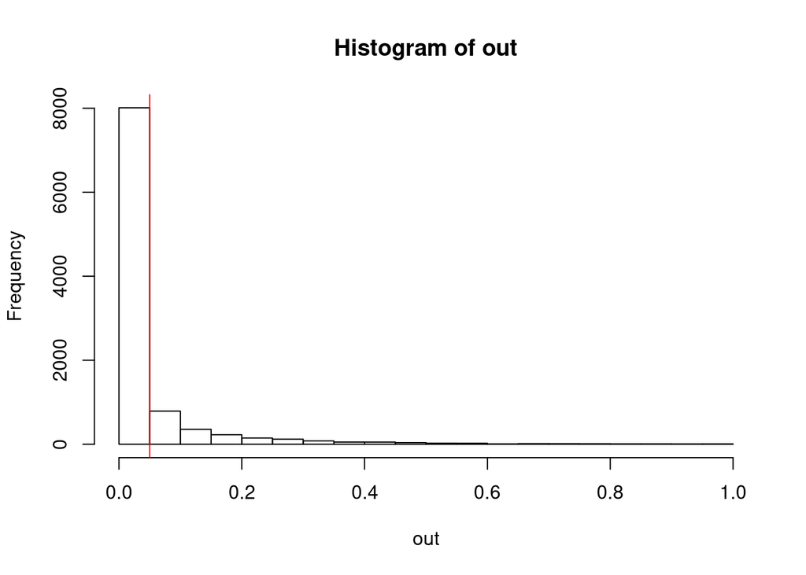

```r
# Sample size of the intervention arm (NutriCare)
n.int <- 75
# Sample size of the control arm (NutriTool)
n.con <- 75

# Function for simulating distributions as a function of means and sample sizes
simfun.wilcox <- function(n1 = n.int, n2 = n.con, mu1 = 1, mu2 = mu1) {
  # Normally distributed values
  x1 <- rnorm(n1, 1 / mu1)
  x2 <- rnorm(n2, 1 / mu2)
  wilcox.test(x1, x2)$p.value
}


set.seed(876543)

# Set effect size to 1.9-fold change, replicate 1000 times
out <- replicate(10000, simfun.wilcox(mu1 = 1, mu2 = 1.9))
hist(out)
abline(v=0.05,col='red')
```

```r
mean(out <= 0.05)
```

```
## [1] 0.8011
```

Mann Whitney Wilcoxon test suggest that 75 patients per arm will give 80% power to detect a 1.9-fold change in mGPS.

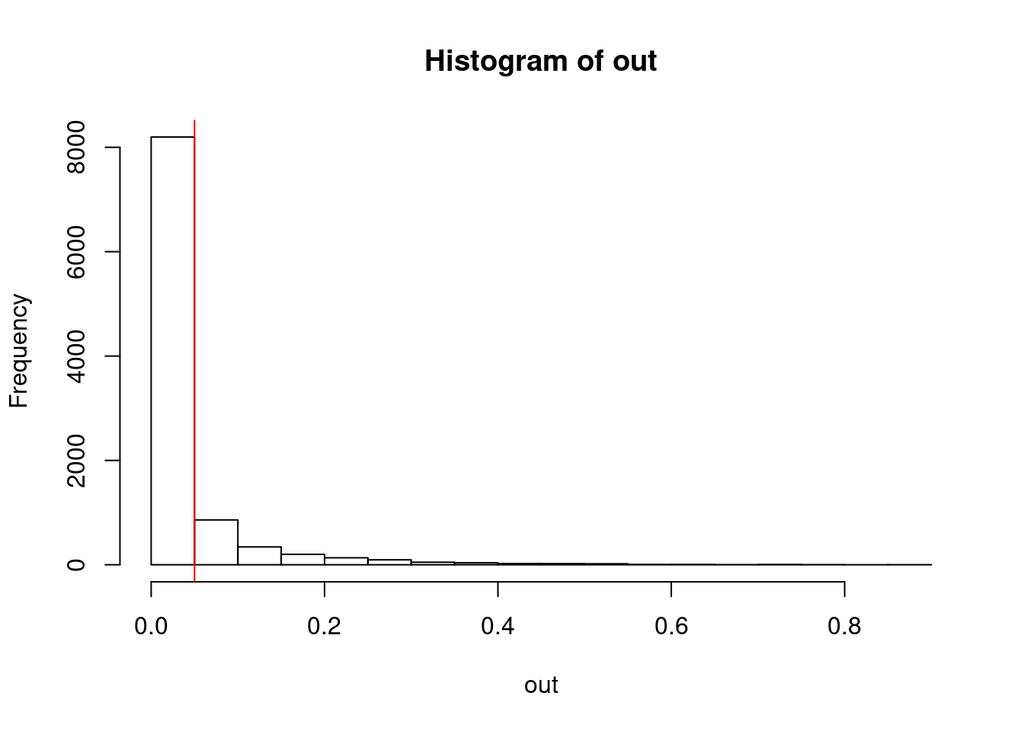

```r
simfun.t <- function(n1 = n.int, n2 = n.con, mu1 = 1, mu2 = mu1){
x1 <- rnorm(n1, 1/mu1)
x2 <- rnorm(n2, 1/mu2)
t.test(x1,x2, alternative = "g")$p.value
}

set.seed(876543)
out <- replicate(10000, simfun.t(mu1=1,mu2=1.73))
hist(out)
abline(v=0.05,col='red')
```

```r
mean(out <= 0.05)
```

```
## [1] 0.8198
```

- The MTM (categorical) predictor will be assessed using a Friedman test (non-parametric repeated-measures ANOVA) with the effect size estimated by Kendall’s coefficient of concordance, where the NutriTool arm will be incorporated as another MTM category and the index of the estimate.

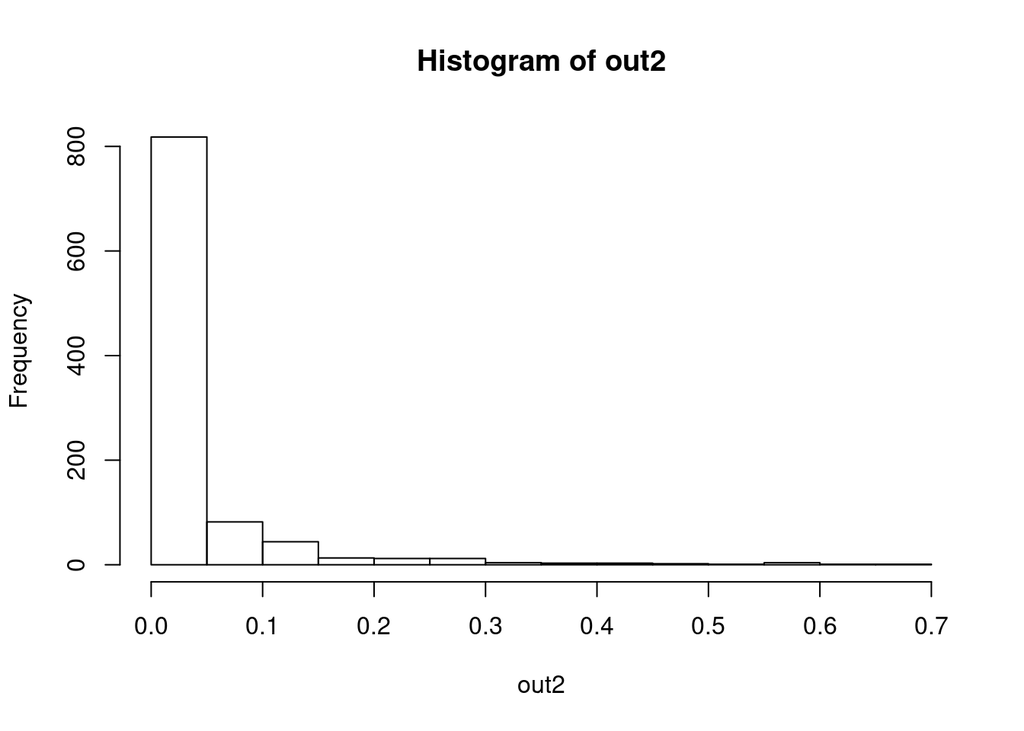

```r
simfun <- function(nblocks = 10,
                   means = c(1, 1),
                   within.sd = 1,
                   between.sd = 1) {
  g <- factor(rep(seq_len(nblocks), each=length(means)))
  t <- rep(seq_along(means), nblocks)
  y <- means[t] + rnorm(nblocks, 0, between.sd)[g] +
    rnorm(length(g),0, within.sd)
  friedman.test(y ~ t | g)$p.value
}

# test size of test
set.seed(112358)
out2 <- replicate(1000, simfun(nblocks = 12, means = c(1, 1, 1, 2, 2, 2)
                               )
                  )
hist(out2)
```

```r
mean(out2 <= 0.05)
```

```
## [1] 0.818
```

A Friedman test shows 80% power to detect a 2-fold change in means between MTM categories.

# Number of covariates that can be simultaneously estimated in linear models (controlling variables)

[figure not shown]

```r
# 3.3.5.2
###### Power to simultaneously estimate covariates ###########

n = 15
sig.level <- 0.05

# Degrees of freedom for the tests  (X continuous variables - 1)
u <- seq(1, 20)

# Degrees of freedom of the error (v = n − u − 1)
v <- c()

effect.size <- 0.8

for (i in u) {
  v[i] <- pwr.f2.test(u = i, f2 = effect.size, sig.level = sig.level, power = 0.8)$v
}

n <- v + u + 1

df <- data.frame(u = u,
                 v = v,
                 n = n)
df %>%
  filter(n < 70 & n > 5) %>%
  ggplot(aes(n, u)) +
  geom_line(lwd = 1) +
  theme_bw() +
  labs(x = "Sample size",
       y = "Number of Covariates") +
  annotate("text", x = 25, y = 13,
           label = "Power = 80%", size = 3, hjust = 0) +
  annotate("text", x = 25, y = 12,
           label = "alpha = 0.05", size = 3, hjust = 0) +
  annotate("text", x = 25, y = 11,
           label = "Effect size = 0.35", size = 3, hjust = 0)
```

## Repoducibility

**Reproducibility receipt**

```r
# Date and time
Sys.time()
```

```
## [1] "2020-06-17 23:29:13 EDT"
```

```r
# Repository
git2r::repository()
```

```
## Local:    master /users/PCON0005/cond0107/github/nutricare
## Remote:   master @ origin (https://github.com/spakowiczlab/nutricare)
## Head:     [fe55f01] 2020-06-18: Update power-calc.Rmd
```